# Supervised Learning and Visualization Practical 2

```r
max(Smarket$Volume) # the value of the higest volume
```

```
## [1] 2.33083
```

17. Use `geom_label(aes(x = your_x, y = your_y, label = "Peak volume"))` to add a label to this day. You can use either the values or call the functions. Place the label near the peak!

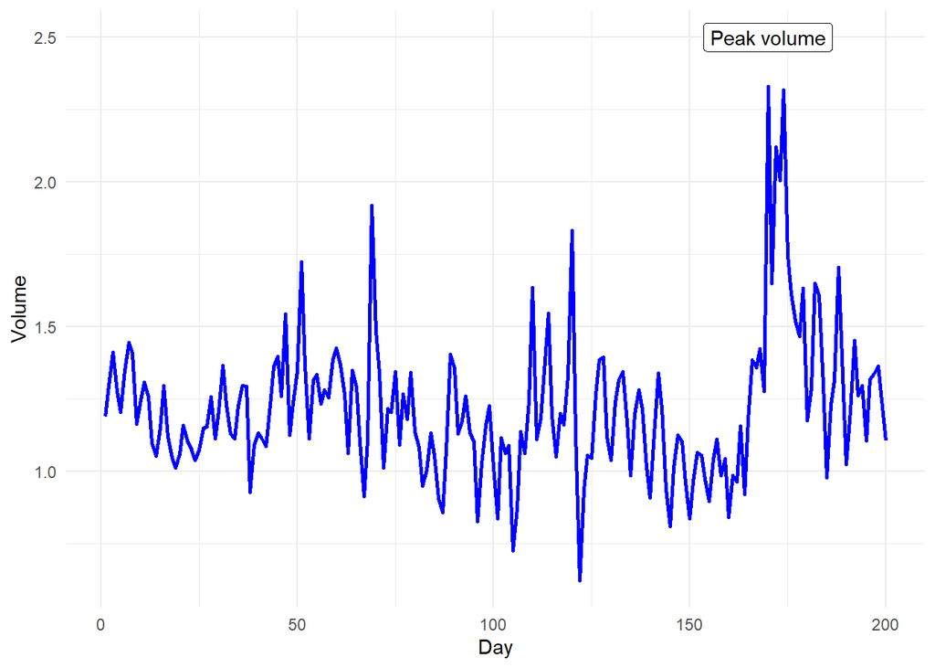

```r
ggplot(Smarket, aes(x = Day, y = Volume))+
  geom_line(color = "blue", size = 1)+
  geom_label(aes(x = 170, y = 2.5, label = "Peak volume"))+
  theme_minimal()
```

18. Create a data frame called baseball based on the `Hitters` dataset. In this data frame, create a factor variable which splits players’ salary range into 3 categories. Tip: use the `filter()` function to remove the missing values, and then use the `cut()` function and assign nice labels to the categories. In addition, create a variable which indicates the proportion of career hits that was a home run.

```r
newhitters <- Hitters %>%
  filter(!is.na(Salary)) %>%
  mutate(SalaryCat = cut(Salary, breaks = 3,
         labels = c("Low salary", "Medium salary", "High salary")),
         Proportion_Hits_HomeRun = CHmRun/CHits)
```

19. Create a scatter plot where you map `CWalks` to the x position and the `proportion` you calculated in the previous exercise to the y position. Fix the y axis limits to (0, 0.4) and the x axis to (0, 1600) using ylim() and xlim(). Add nice x and y axis titles using the labs() function. Save the plot as the variable `baseball_plot`.

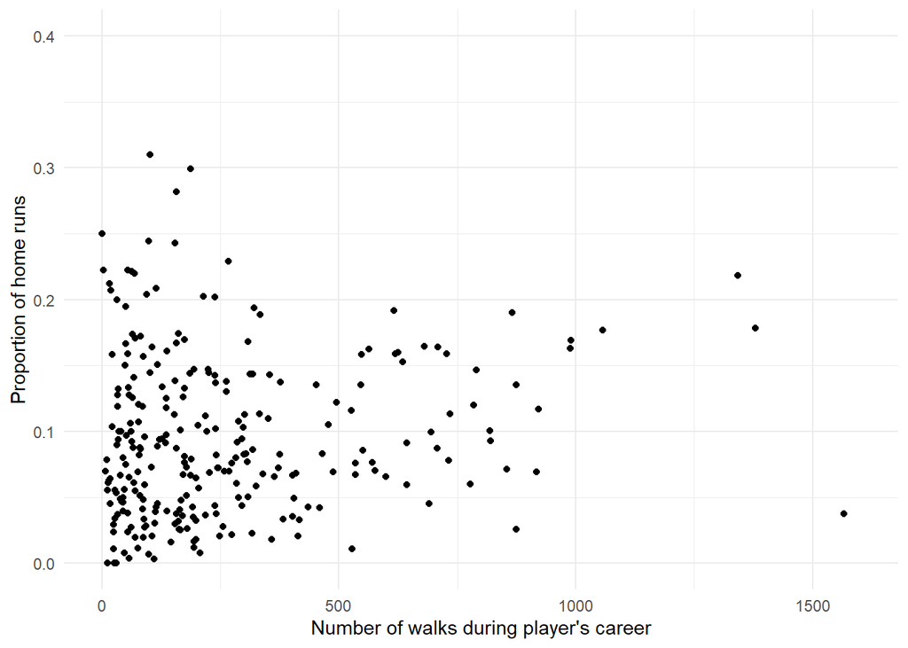

```r
baseball_plot <-
  ggplot(newhitters, aes(x = CWalks, y = Proportion_Hits_HomeRun))+
  geom_point()+
  ylim(0, 0.4)+
  xlim(0, 1600)+
  labs(x = "Number of walks during player's career", y = "Proportion of home runs")+
  theme_minimal()


baseball_plot
```

20. Split up this plot into three parts based on the salary range variable you calculated. Use the `facet_wrap()` function for this; look at the examples in the help file for tips.

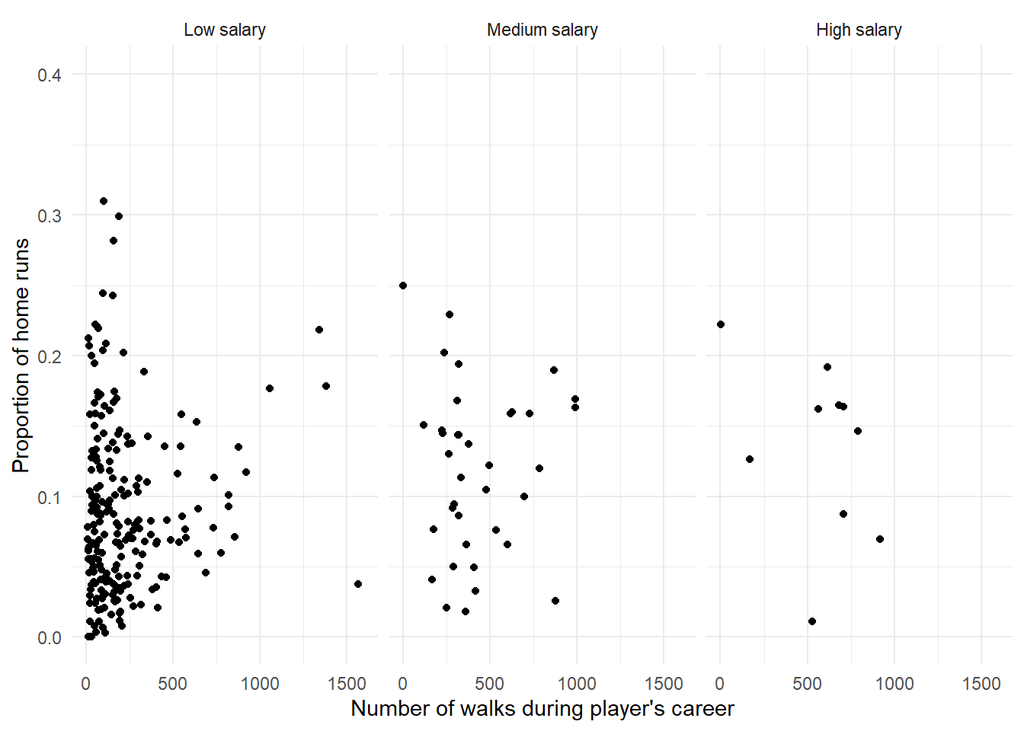

```r
baseball_plot + facet_wrap(vars(SalaryCat))
```

21. Create an interesting data visualisation based on the `Carseats` data from the `ISLR` package.

```r
carseats <- Carseats %>%
  mutate(PriceDiff = CompPrice - Price) %>%
  mutate(IncomeCat = cut(Income, breaks = 3,
         labels = c("Low income", "Medium income", "High income"))) %>%
  mutate(Advertising = cut(Advertising, breaks = 3,
         labels = c("Low advertising", "Medium advertising", "High advertising")))
```

I compute the price difference between the competitor and our location. Higher difference values indicate that our location is cheaper than the competitors. Next, I split Income and Advertising into three categories.

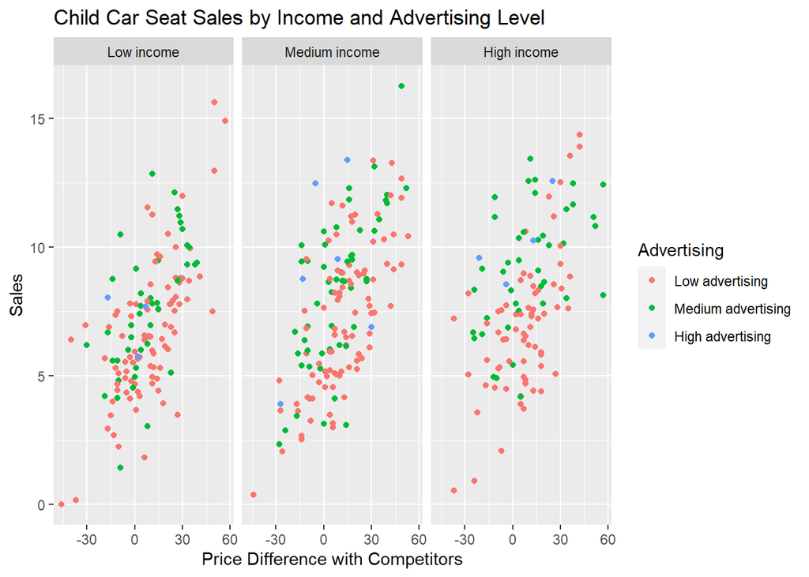

```r
ggplot(carseats, aes(x = PriceDiff, y = Sales, color = Advertising))+
  geom_point()+
  facet_wrap(vars(IncomeCat))+
  labs(x = "Price Difference with Competitors",
       y = "Sales",
       title = "Child Car Seat Sales by Income and Advertising Level")
```

The end.